# Time series analysis project

## UCM

Training and validation set for ucm models are created respectively using 80% - 20% of data. Models are trined and evaluated on scaled data. Variance of training set is extracted to initialize optimization parameters.

```r
train_ucm <- ts(ts_stand[1:as.integer(nrow(ts_stand)*0.8), ],
                frequency = 24,
                start = 1)

validation_ucm <- ts(ts_stand[(1 + as.integer(nrow(ts_stand)*0.8)) : nrow(ts_stand), ],
                     frequency = 24,
                     start = 585)

v_train_ucm <- var(train_ucm)
```

Firs UCM trained is a simple Local Linear Trend, MAE obtained is 0.6857667. Plot 13 show prevision made with this model.

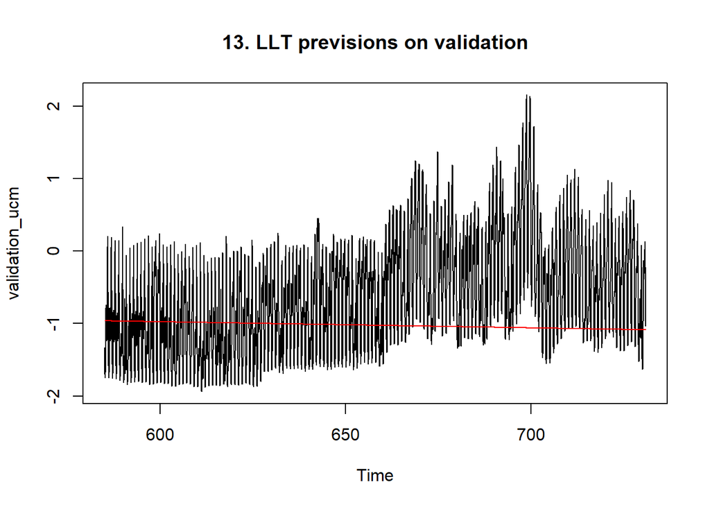

LLT with daily stochastic dummy.

Seasonal dummys are used to insert in the model daily seasonality. As seen before it is necessary to model this seasonality which represent a strong component of this TS. With this model a MAE of 0.511847 is obtained. Focus of prevision made in first and last week are shown in plot 14.1 and 14.2. This model capture really well the daily seasonality.

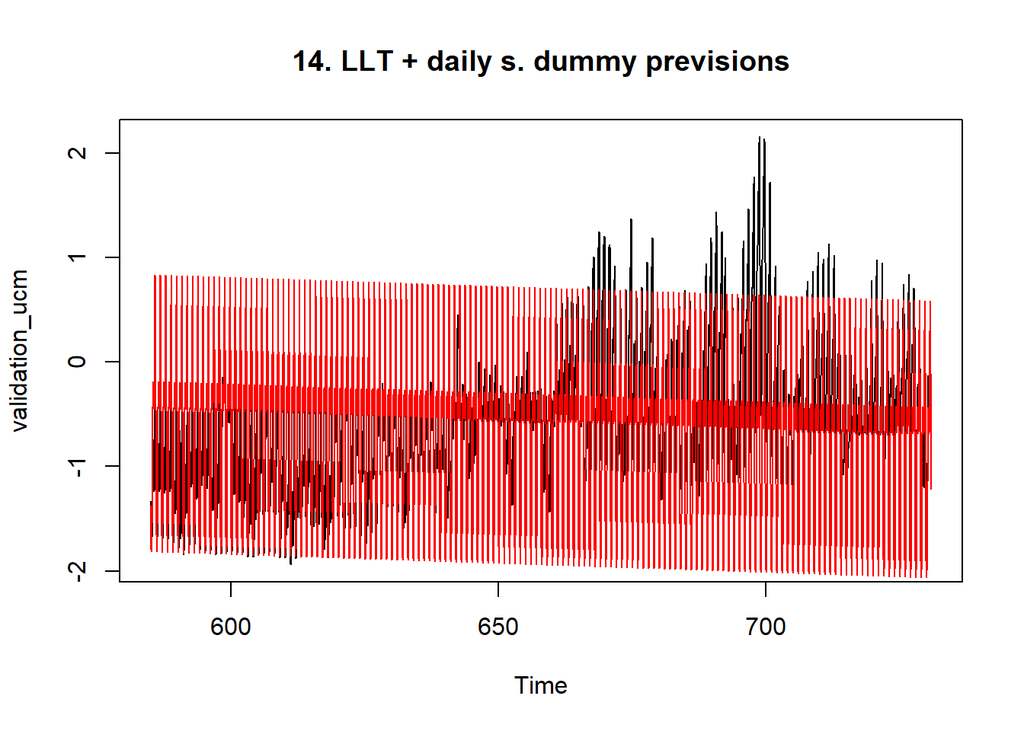

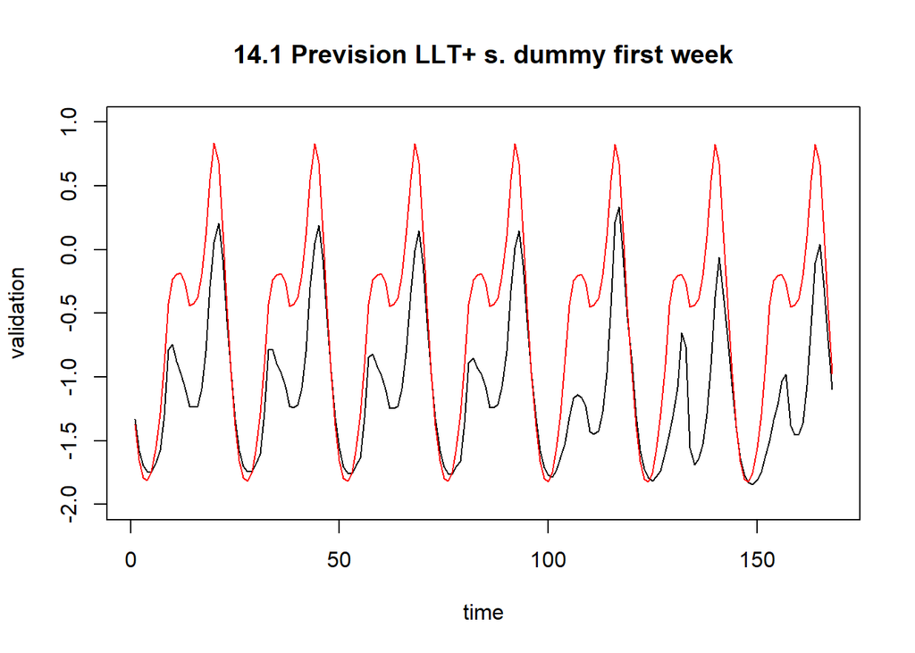

```
## integer(0)
```

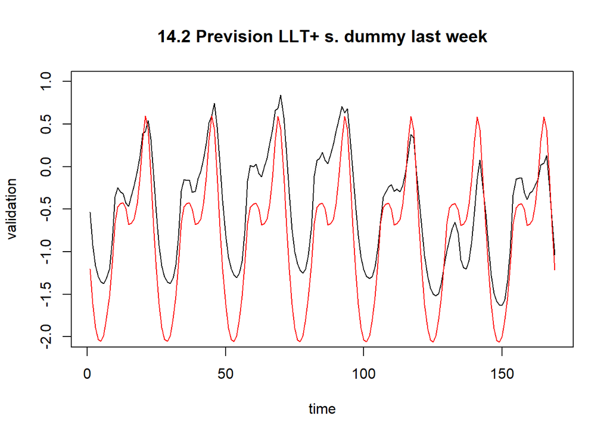

```
## integer(0)
```

To be sure to take in account all aspect of forecasting, a cyclic component is added to the prevoius model. Considering that a cyclic pattern exists when data exhibit rises and falls that are not of fixed period and that the duration of these fluctuations is usually of at least 2 years. MAE of this model (0.5731635) increase compared to LLT+seasonal dummy model.

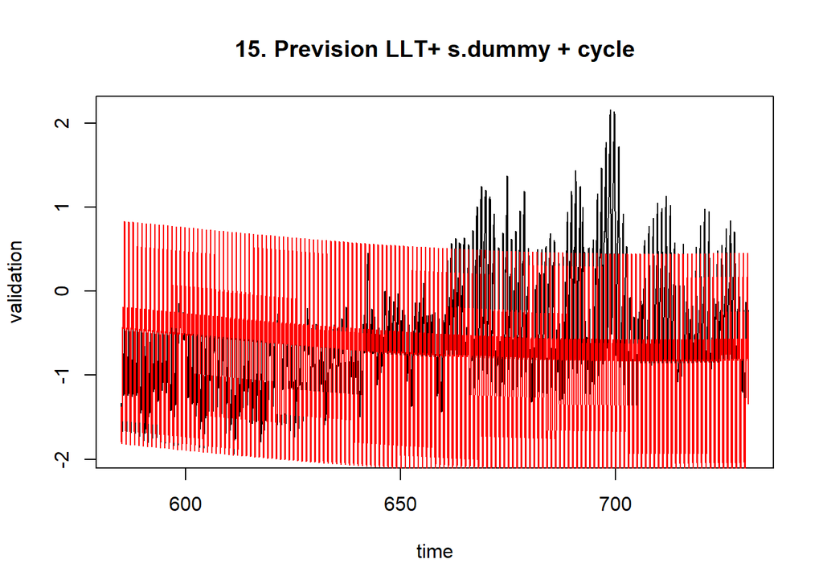

Model with trigonometric seasonality is trained but it has no good result in term of MAE on validation set (MAE=0.6601218).